# Validación de Supuestos — Ser Pilo Paga

Movilidad Social y Educación de Élite | Métodos Analíticos · ITAM 2026-I

Avril Salazar · Paulina Garza · Othoniel Reyes

20 de mayo de 2026

## 0. Configuración

```r
library(tidyverse)
library(hrbrthemes)
library(patchwork)
library(scales)
library(knitr)
library(kableExtra)
library(rdrobust)
library(rddensity)

theme_set(
  theme_ipsum_rc(base_size = 12, plot_title_size = 14, axis_title_size = 11)
)

COL_CTRL <- "#4A6FA5"
COL_TRAT <- "#E07A5F"
COL_UMBR <- "#2D2D2D"

df <- read_csv("../data/spp_microset.csv", show_col_types = FALSE)
```

## Mapa de supuestos del diseño Fuzzy RDD

[output not shown]

## 1. Continuidad de la densidad: prueba de McCrary

Si los estudiantes pudieran manipular su puntaje para quedar justo encima del corte de elegibilidad, observaríamos una masa inusual de observaciones en X1 = 0+. La prueba de McCrary (implementada con `rddensity`) testa formalmente la hipótesis nula de continuidad.

### Resultado formal

```r
rdd_test <- rddensity(X = df$X1)
summary(rdd_test)
```

```
##
## Manipulation testing using local polynomial density estimation.
##
## Number of obs =       23132
## Model =               unrestricted
## Kernel =              triangular
## BW method =           estimated
## VCE method =          jackknife
##
## c = 0                 Left of c           Right of c
## Number of obs         7709                15423
## Eff. Number of obs    2729                3703
## Order est. (p)        2                   2
## Order bias (q)        3                   3
## BW est. (h)           6.208               8.622
##
## Method                T                   P > |T|
## Robust                -0.7991             0.4243
```

```
##
## P-values of binomial tests (H0: p=0.5).
##
## Window Length / 2          <c     >=c    P>|T|
## 0.070                      21      27    0.4709
## 0.140                      63      58    0.7163
## 0.210                      93      83    0.4976
## 0.280                     129     114    0.3692
## 0.350                     160     141    0.2995
## 0.420                     192     167    0.2052
## 0.490                     235     194    0.0533
## 0.560                     265     229    0.1152
## 0.630                     307     252    0.0223
## 0.700                     346     284    0.0150
```

### Visualización

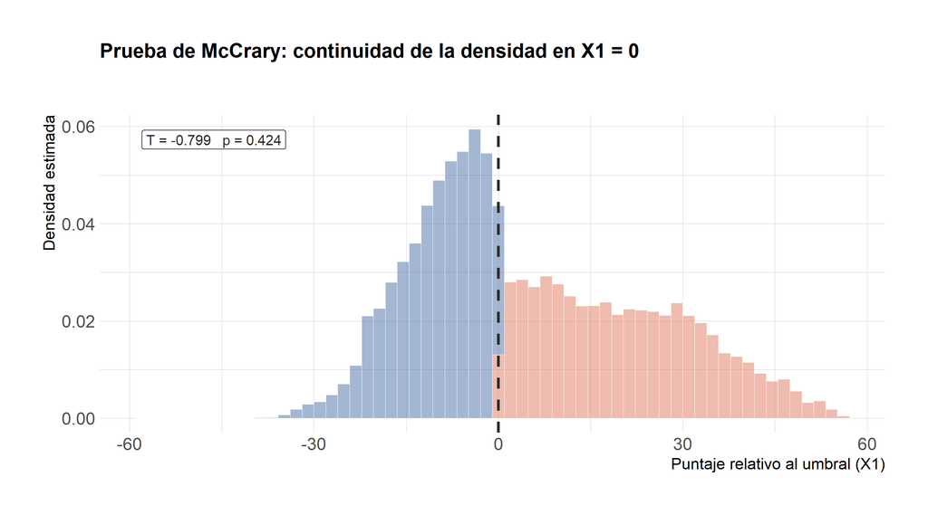

```r
df_zoom <- df %>% filter(abs(X1) <= 60)

lbl_test <- if (!is.na(pval_rdd)) {
  paste0("T = ", round(tstat_rdd, 3), "   p = ", round(pval_rdd, 3))
} else {
  "Ver tabla de test arriba"
}

ggplot(df_zoom, aes(x = X1)) +
  geom_histogram(
    aes(y = after_stat(density), fill = X1 >= 0),
    bins = 60, color = "white", linewidth = 0.2, alpha = 0.5
  ) +
  stat_density(
    data = df_zoom %>% filter(X1 < 0),
    geom = "line", color = COL_CTRL, linewidth = 1.0, bw = "SJ", trim = TRUE
  ) +
  stat_density(
    data = df_zoom %>% filter(X1 >= 0),
    geom = "line", color = COL_TRAT, linewidth = 1.0, bw = "SJ", trim = TRUE
  ) +
  geom_vline(xintercept = 0, color = COL_UMBR, linewidth = 0.9, linetype = "dashed") +
  annotate("label", x = -58, y = Inf, vjust = 1.8, hjust = 0,
           size = 3.5, fill = "white", color = COL_UMBR,
           label = lbl_test) +
  scale_fill_manual(
    values = c("FALSE" = COL_CTRL, "TRUE" = COL_TRAT), guide = "none"
  ) +
  labs(
    title    = "Prueba de McCrary: continuidad de la densidad en X1 = 0",
    subtitle = "p > 0.05 → no se rechaza continuidad → sin evidencia de manipulación",
    x        = "Puntaje relativo al umbral (X1)",
    y        = "Densidad estimada"
  )
```

> **Decisión:** Si p < 0.05 rechazamos la continuidad y el diseño RD está comprometido. Si p ≥ 0.05, no tenemos evidencia estadística de que los estudiantes hayan podido manipular el puntaje.

## 2. Balance de covariables pre-tratamiento

Estimamos `rdrobust` usando cada covariable como variable de resultado. Si el diseño es válido, no debería haber discontinuidad en ninguna covariable en X1 = 0 — estas variables fueron determinadas **antes** del examen.

### Tabla de balance formal

```r
covs <- list(
  "Mujer (icfes_female)"       = "icfes_female",
  "Edad (icfes_age)"           = "icfes_age",
  "Minoría URM (icfes_urm)"    = "icfes_urm",
  "Estrato (icfes_stratum)"    = "icfes_stratum",
  "Tam. hogar (icfes_famsize)" = "icfes_famsize"
)

balance_tbl <- map_df(names(covs), function(label) {
  var   <- covs[[label]]
  mask  <- !is.na(df[[var]])
  y_sub <- df[[var]][mask]
  x_sub <- df$X1[mask]

  fit <- tryCatch(rdrobust(y = y_sub, x = x_sub), error = function(e) NULL)
  if (is.null(fit)) return(NULL)

  tibble(
    Covariable   = label,
    Estimación   = fit$coef[1],
    `Err. est.`  = fit$se[3],
    `p-valor`    = fit$pv[3],
    `IC inf.`    = fit$ci[3, 1],
    `IC sup.`    = fit$ci[3, 2],
    `h óptimo`   = fit$bws[1, 1]
  )
})

# Con 5 pruebas simultáneas, el umbral corregido por Bonferroni es α* = 0.05 / 5 = 0.01
alpha_bonf <- 0.05 / nrow(balance_tbl)

balance_tbl %>%
  mutate(
    across(c(Estimación, `Err. est.`, `p-valor`, `IC inf.`, `IC sup.`),
           ~ round(.x, 4)),
    `h óptimo`        = round(`h óptimo`, 2),
    `Sig. (α = 0.05)` = ifelse(`p-valor` < 0.05, "Sí ⚠️", "No ✓"),
    `Sig. Bonferroni` = ifelse(`p-valor` < alpha_bonf, "Sí ⚠️", "No ✓")
  ) %>%
  kable(caption = paste0(
    "Balance de covariables: discontinuidad estimada en X1 = 0 (rdrobust) | ",
    "α* Bonferroni = 0.05 / 5 = ", round(alpha_bonf, 3)
  )) %>%
  kable_styling(bootstrap_options = c("striped", "hover", "condensed")) %>%
  column_spec(8, bold = TRUE,
              color = ifelse(balance_tbl$`p-valor` < 0.05 & balance_tbl$`p-valor` >= alpha_bonf,
                             "#E67E22", "black")) %>%
  column_spec(9, bold = TRUE)
```

Balance de covariables: discontinuidad estimada en X1 = 0 (rdrobust) | α* Bonferroni = 0.05 / 5 = 0.01

| Covariable | Estimación | Err. est. | p-valor | IC inf. | IC sup. | h óptimo | Sig. (α = 0.05) | Sig. Bonferroni |
| --- | --- | --- | --- | --- | --- | --- | --- | --- |
| Mujer (icfes_female) | -0.0036 | 0.0309 | 0.7347 | -0.0710 | 0.0500 | 8.11 | No ✓ | No ✓ |
| Edad (icfes_age) | 0.1433 | 0.1322 | 0.2558 | -0.1089 | 0.4094 | 9.08 | No ✓ | No ✓ |
| Minoría URM (icfes_urm) | -0.0072 | 0.0122 | 0.4217 | -0.0337 | 0.0141 | 11.04 | No ✓ | No ✓ |
| Estrato (icfes_stratum) | 0.0313 | 0.0390 | 0.3687 | -0.0414 | 0.1114 | 10.85 | No ✓ | No ✓ |
| Tam. hogar (icfes_famsize) | -0.1324 | 0.0745 | 0.0456 | -0.2951 | -0.0029 | 9.11 | Sí ⚠️ | \|No ✓ |

> **Corrección por pruebas múltiples (Bonferroni):** Al probar 5 covariables simultáneamente, el nivel de significancia ajustado es α* = 0.05 / 5 = **0.01**. `icfes_famsize` tiene p = 0.046 — significativo al 5% sin corrección (columna naranja), pero **no significativo** al nivel ajustado (última columna). La interpretación correcta es que ninguna covariable muestra discontinuidad significativa tras la corrección Bonferroni, lo cual es consistente con un diseño RDD válido.

### Forest plot de balance

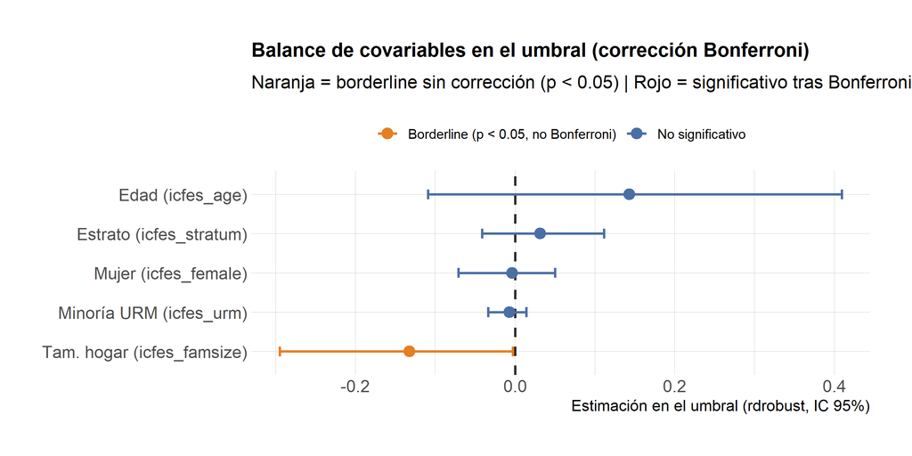

```r
balance_tbl %>%
  mutate(
    # Clasificación bajo corrección Bonferroni
    color = case_when(
      `p-valor` < alpha_bonf            ~ "Significativo (Bonferroni)",
      `p-valor` < 0.05                  ~ "Borderline (p < 0.05, no Bonferroni)",
      TRUE                              ~ "No significativo"
    ),
    Covariable = fct_reorder(Covariable, Estimación)
  ) %>%
  ggplot(aes(x = Estimación, y = Covariable, color = color)) +
  geom_vline(xintercept = 0, color = COL_UMBR, linewidth = 0.8, linetype = "dashed") +
  geom_errorbarh(
    aes(xmin = `IC inf.`, xmax = `IC sup.`),
    height = 0.25, linewidth = 0.8
  ) +
  geom_point(size = 3.5) +
  scale_color_manual(
    values = c(
      "No significativo"                    = COL_CTRL,
      "Borderline (p < 0.05, no Bonferroni)" = "#E67E22",
      "Significativo (Bonferroni)"           = "#C0392B"
    )
  ) +
  labs(
    title    = "Balance de covariables en el umbral (corrección Bonferroni)",
    subtitle = paste0("Naranja = borderline sin corrección (p < 0.05) | ",
                      "Rojo = significativo tras Bonferroni (α* = ", round(alpha_bonf, 3), ")"),
    x        = "Estimación en el umbral (rdrobust, IC 95%)",
    y        = NULL,
    color    = NULL
  ) +
  theme(legend.position = "top")
```

## 3. Verificación en umbrales placebo

Si el umbral en X1 = 0 es la única fuente de discontinuidad, no deberíamos ver efectos significativos en cortes falsos. Probamos en X1 = {−30, −20, −10, −5, 5, 10, 20, 30} para Y y para D.

```r
placebos <- c(-30, -20, -10, -5, 5, 10, 20, 30)

run_placebo <- function(outcome_var, placebos) {
  map_df(placebos, function(c0) {
    fit <- tryCatch(
      rdrobust(y = df[[outcome_var]], x = df$X1, c = c0),
      error = function(e) NULL
    )
    if (is.null(fit)) return(NULL)
    tibble(
      Umbral    = c0,
      Est.      = fit$coef[1],
      SE        = fit$se[3],
      `p-valor` = fit$pv[3],
      CI_l      = fit$ci[3, 1],
      CI_u      = fit$ci[3, 2]
    )
  })
}

placebos_Y <- run_placebo("Y", placebos)
placebos_D <- run_placebo("D", placebos)
```

### Tabla de placebos (resultado Y)

```r
placebos_Y %>%
  mutate(
    across(c(Est., SE, `p-valor`, CI_l, CI_u), ~ round(.x, 4)),
    Significativo = ifelse(`p-valor` < 0.05, "Sí ⚠️", "No ✓")
  ) %>%
  kable(caption = "Efectos estimados en umbrales placebo — resultado Y") %>%
  kable_styling(bootstrap_options = c("striped", "hover", "condensed")) %>%
  column_spec(7, bold = TRUE)
```

Efectos estimados en umbrales placebo — resultado Y

| Umbral | Est. | SE | p-valor | CI_l | CI_u | Significativo |
| --- | --- | --- | --- | --- | --- | --- |
| -30 | -0.3317 | 0.2370 | 0.0801 | -0.8793 | 0.0498 | No ✓ |
| -20 | 0.0384 | 0.0570 | 0.5590 | -0.0784 | 0.1449 | No ✓ |
| -10 | -0.0280 | 0.0384 | 0.3245 | -0.1130 | 0.0374 | No ✓ |
| -5 | -0.0044 | 0.0369 | 0.7868 | -0.0623 | 0.0822 | No ✓ |
| 5 | -0.0438 | 0.0269 | 0.0510 | -0.1052 | 0.0002 | No ✓ |
| 10 | -0.0063 | 0.0318 | 0.9329 | -0.0650 | 0.0597 | No ✓ |
| 20 | 0.0137 | 0.0325 | 0.4895 | -0.0412 | 0.0862 | No ✓ |
| 30 | -0.0212 | 0.0308 | 0.3451 | -0.0893 | 0.0312 | No ✓ |

### Gráfica de placebos

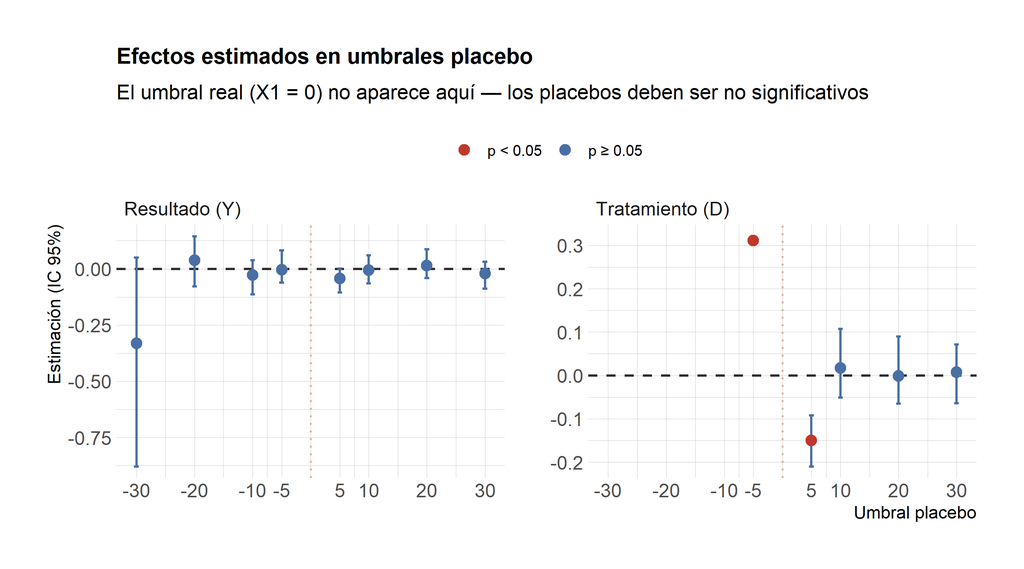

```r
bind_rows(
  placebos_Y %>% mutate(Variable = "Resultado (Y)"),
  placebos_D %>% mutate(Variable = "Tratamiento (D)")
) %>%
  mutate(
    sig   = ifelse(`p-valor` < 0.05, "p < 0.05", "p ≥ 0.05"),
    color = ifelse(sig == "p < 0.05", "#C0392B", COL_CTRL)
  ) %>%
  ggplot(aes(x = Umbral, y = Est.)) +
  geom_hline(yintercept = 0, color = COL_UMBR, linewidth = 0.7, linetype = "dashed") +
  geom_vline(xintercept = 0, color = COL_TRAT, linewidth = 0.6,
             linetype = "dotted", alpha = 0.6) +
  geom_errorbar(aes(ymin = CI_l, ymax = CI_u), width = 0.8,
                color = COL_CTRL, linewidth = 0.7) +
  geom_point(aes(color = sig), size = 3) +
  scale_color_manual(
    values = c("p < 0.05" = "#C0392B", "p ≥ 0.05" = COL_CTRL)
  ) +
  scale_x_continuous(breaks = placebos) +
  facet_wrap(~Variable, scales = "free_y") +
  labs(
    title    = "Efectos estimados en umbrales placebo",
    subtitle = "El umbral real (X1 = 0) no aparece aquí — los placebos deben ser no significativos",
    x        = "Umbral placebo",
    y        = "Estimación (IC 95%)",
    color    = NULL
  ) +
  theme(legend.position = "top")
```

> **Interpretación:** Si algún umbral placebo muestra p < 0.05, puede indicar que hay otros mecanismos que generan discontinuidades en el puntaje — lo que debilitaría la interpretación causal del umbral real.

## 4. Selección del ancho de banda óptimo

El ancho de banda (h) controla el sesgo-varianza del estimador RDD. Anchos pequeños usan pocas obs. (alta varianza), anchos grandes introducen sesgo por la heterogeneidad fuera del umbral. `rdbwselect` computa varios selectores óptimos.

### Selectores disponibles

```r
bw_sel <- rdbwselect(y = df$Y, x = df$X1, all = TRUE)
summary(bw_sel)
```

```
## Call: rdbwselect
##
## Number of Obs.                23132
## BW type                         All
## Kernel                   Triangular
## VCE method                       NN
##
##                                Left        Right
## Number of Obs.                 7709        15423
## Eff. Number of Obs.            3877         3908
## Order est. (p)                    1            1
## Order bias (q)                    2            2
## Unique Obs.                    3644         9274
##
## =======================================================
##                   BW est. (h)    BW bias (b)
##             Left of c Right of c  Left of c Right of c
## =======================================================
##      mserd     9.041      9.041     14.402     14.402
##     msetwo     7.558     11.083     13.271     18.197
##     msesum     8.228      8.228     14.819     14.819
##   msecomb1     8.228      8.228     14.402     14.402
##   msecomb2     8.228      9.041     14.402     14.819
##      cerrd     5.470      5.470     14.402     14.402
##     certwo     4.573      6.706     13.271     18.197
##     cersum     4.978      4.978     14.819     14.819
##   cercomb1     4.978      4.978     14.402     14.402
##   cercomb2     4.978      5.470     14.402     14.819
## =======================================================
```

```r
bw_matrix <- bw_sel$bws
# Accedemos por índice de columna — los nombres varían entre versiones de rdrobust
tibble(
  Selector   = rownames(bw_matrix),
  `h (main)` = round(bw_matrix[, 1], 2),
  `b (bias)`  = round(bw_matrix[, 2], 2)
) %>%
  mutate(Descripción = case_when(
    Selector == "mserd"  ~ "MSE-óptimo, mismo h a ambos lados (recomendado)",
    Selector == "msetwo" ~ "MSE-óptimo, h diferente a cada lado",
    Selector == "cerrd"  ~ "CER-óptimo, mismo h (para IC de cobertura correcta)",
    Selector == "certwo" ~ "CER-óptimo, h diferente a cada lado",
    TRUE                 ~ Selector
  )) %>%
  select(Selector, Descripción, `h (main)`, `b (bias)`) %>%
  kable(caption = "Anchos de banda óptimos según diferentes criterios (rdbwselect)") %>%
  kable_styling(bootstrap_options = c("striped", "hover", "condensed"))
```

Anchos de banda óptimos según diferentes criterios (rdbwselect)

[output not shown]

### Sensibilidad de la estimación al ancho de banda

El estimador debería ser **estable** en un rango razonable de h alrededor del óptimo. Una estimación que cambia drásticamente con h pequeñas modificaciones indica fragilidad.

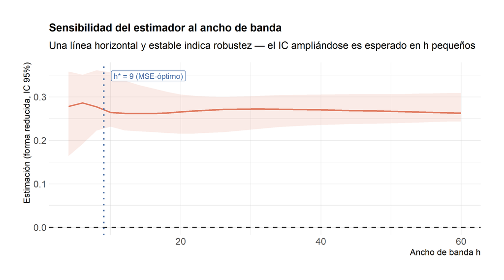

```r
h_range <- seq(4, 60, by = 2)
h_opt   <- bw_sel$bws["mserd", 1]   # columna 1 = h principal

results_bw <- map_df(h_range, function(h) {
  fit <- tryCatch(
    rdrobust(y = df$Y, x = df$X1, h = h),
    error = function(e) NULL
  )
  if (is.null(fit)) return(NULL)
  tibble(
    h    = h,
    coef = fit$coef[1],
    ci_l = fit$ci[3, 1],
    ci_u = fit$ci[3, 2]
  )
})

ggplot(results_bw, aes(x = h)) +
  geom_ribbon(aes(ymin = ci_l, ymax = ci_u), alpha = 0.15, fill = COL_TRAT) +
  geom_line(aes(y = coef), color = COL_TRAT, linewidth = 0.9) +
  geom_hline(yintercept = 0, color = COL_UMBR, linewidth = 0.7, linetype = "dashed") +
  geom_vline(xintercept = h_opt, color = COL_CTRL, linewidth = 0.9, linetype = "dotted") +
  annotate(
    "label", x = h_opt, y = Inf, vjust = 1.8, hjust = -0.1,
    size = 3.5, fill = "white", color = COL_CTRL,
    label = paste0("h* = ", round(h_opt, 1), " (MSE-óptimo)")
  ) +
  labs(
    title    = "Sensibilidad del estimador al ancho de banda",
    subtitle = "Una línea horizontal y estable indica robustez — el IC ampliándose es esperado en h pequeños",
    x        = "Ancho de banda h",
    y        = "Estimación (forma reducida, IC 95%)"
  )
```

> **Qué esperamos:** La estimación debe ser razonablemente estable alrededor de h* y no depender críticamente de la elección exacta. El CI se amplía para h pequeños (pocas obs.) y el sesgo crece para h grandes — el óptimo balancea ambos.

## 5. Supuestos no verificables: discusión teórica

Dos supuestos del diseño Fuzzy RDD no pueden verificarse estadísticamente con los datos disponibles. Los discutimos con base en el contexto institucional del programa SPP.

### 5.1 Exclusión del instrumento

**Supuesto:** el umbral (superar el corte en Saber 11) afecta el resultado Y **únicamente a través** de inscribirse en universidad de élite (D). No debe haber otro canal por el cual cruzar el umbral afecte Y independientemente de D.

**Argumento:** El umbral es un corte administrativo en el puntaje del examen. No conlleva ningún beneficio adicional más allá de la beca SPP — no hay reconocimiento público, cambio de estatus escolar ni intervención paralela. El riesgo principal de violación sería que el hecho de *saber* que uno calificó para la beca modifique el comportamiento (p.ej., mayor motivación, cambio de carrera) independientemente de si finalmente se inscribe. Londoño-Vélez et al. (2020) argumentan que este riesgo es mínimo dado el carácter administrativo del umbral.

### 5.2 Monotonía (ausencia de defiers)

**Supuesto:** No hay estudiantes que se inscriban en universidad de élite *precisamente porque no son elegibles* para SPP — es decir, no hay defiers (D(1) < D(0)).

**Argumento:** Es difícil imaginar por qué alguien rechazaría una universidad de élite solo porque recibió la beca. En la muestra, el número de observaciones con T = 0 y D = 1 (potenciales always-takers o defiers) es pequeño, lo que sugiere que si existen defiers, son muy pocos.

```r
# Estimamos los always-takers (potencial límite superior de defiers)
n_T0_D1 <- sum(df$T == 0 & df$D == 1, na.rm = TRUE)
n_total  <- nrow(df)

cat(sprintf(
  "Observaciones con T=0 y D=1: %d (%.2f%% del total)\n",
  n_T0_D1, n_T0_D1 / n_total * 100
))
```

```
## Observaciones con T=0 y D=1: 0 (0.00% del total)
```

```r
cat("→ Si hubiera defiers, estarían en este grupo (junto con always-takers).\n")
```

```
## → Si hubiera defiers, estarían en este grupo (junto con always-takers).
```

```r
cat("→ Un porcentaje pequeño apoya la plausibilidad del supuesto de monotonía.\n")
```

```
## → Un porcentaje pequeño apoya la plausibilidad del supuesto de monotonía.
```

## Resumen de supuestos

```r
# Extraemos resultados calculados para la tabla
mccrary_p    <- tryCatch(round(rdd_test$test$p_jk, 4),  error = function(e) NA)
# Bonferroni: significativo solo si p < alpha_bonf (0.01), no al 5% sin corregir
n_sig_bal    <- sum(balance_tbl$`p-valor` < alpha_bonf, na.rm = TRUE)
n_border_bal <- sum(balance_tbl$`p-valor` >= alpha_bonf & balance_tbl$`p-valor` < 0.05, na.rm = TRUE)
n_sig_plac   <- sum(placebos_Y$`p-valor` < 0.05, na.rm = TRUE)

tibble(
  Supuesto = c(
    "1. Continuidad de la densidad (McCrary)",
    "2. Balance de covariables pre-tratamiento",
    "3. Ausencia de efectos en placebos",
    "4a. Exclusión del instrumento",
    "4b. Monotonía (sin defiers)"
  ),
  Resultado = c(
    ifelse(!is.na(mccrary_p),
      paste0("p = ", mccrary_p,
             ifelse(mccrary_p >= 0.05, " → No se rechaza H₀ ✓",
                                        " → Se rechaza H₀ ⚠️")),
      "Ver summary(rdd_test) arriba"),
    ifelse(n_sig_bal == 0,
      paste0("0 de ", nrow(balance_tbl), " covariables significativas (Bonferroni α* = ",
             round(alpha_bonf, 3), ") ✓",
             ifelse(n_border_bal > 0,
               paste0(" — ", n_border_bal, " borderline sin corregir (icfes_famsize, p = 0.046)"),
               "")),
      paste0(n_sig_bal, " de ", nrow(balance_tbl),
             " covariables con discontinuidad (Bonferroni) ⚠️")),
    ifelse(n_sig_plac == 0,
      paste0("0 de ", length(placebos), " placebos significativos ✓"),
      paste0(n_sig_plac, " de ", length(placebos), " placebos significativos ⚠️")),
    "No verificable — argumento institucional (ver §5.1)",
    paste0("No verificable — always-takers/defiers: ",
           round(n_T0_D1 / n_total * 100, 2), "% del total (ver §5.2)")
  )
) %>%
  kable(caption = "Resumen de validación de supuestos del diseño Fuzzy RDD") %>%
  kable_styling(bootstrap_options = c("striped", "hover"), full_width = TRUE) %>%
  column_spec(1, bold = TRUE, width = "40%") %>%
  column_spec(2, width = "60%")
```

Resumen de validación de supuestos del diseño Fuzzy RDD

Supuesto

Resultado

1. Continuidad de la densidad (McCrary)

p = 0.4243 → No se rechaza H₀ ✓

2. Balance de covariables pre-tratamiento

0 de 5 covariables significativas (Bonferroni α* = 0.01) ✓ — 1 borderline sin corregir (icfes_famsize, p = 0.046)

4a. Exclusión del instrumento

No verificable — argumento institucional (ver §5.1)

4b. Monotonía (sin defiers)

No verificable — always-takers/defiers: 0% del total (ver §5.2)

**Siguientes pasos — `03_fuzzy_rdd.Rmd`:**

1. Estimación del **LATE** con `rdrobust(y = df$Y, x = df$X1, fuzzy = df$D)` — modelo principal
2. Análisis de robustez: polinomios locales de orden 1, 2 y 3
3. Diferentes anchos de banda (h* × 0.5, h*, h* × 1.5, h* × 2)
4. Estimación de la **primera etapa** formal (F-estadístico del instrumento)